# Resource Selection Function Guide

## Extracting Data

Extracting distance to nearest structure was done using the “near” tool in ArcGIS.This step was done after clipping to MA and data were saved as shapefiles in “Combined, Clipped, Near” folder.

### Urbanization Gradient

To explore if bears selection changes across varying levels of urbanization we calculated the percent impervious surface plus developed open space for each bear’s home range. This is one of the variables that will go into the model.

**Libraries** Make sure to install and pull in the libraries you need in order for your code functions to work.

```r
library(raster)
library(sp)
library(adehabitatHR)
library(adehabitatHS)
library(reshape2)
library(sf)
library(writexl)
```

**Set Paths** Setting paths is important to make sure you are working with data in the correct file folder. It will vary based on where your personal data is stored.

```r
path.root <- "C:/Users/jessi/University of Massachusetts/Jessica-BearProject - General/Final Data"
path.mcp <- paste(path.root, "/MCPs", sep = "")
path.GIS <- paste(path.root, "/GIS Layers", sep = "")
```

**Bring in the land use data**

```r
setwd(path.GIS)
lulc2016 <-raster("LULC2016.tif")
```

**Examine the raster data**

```r
# Check the coordinate reference system
print(crs(lulc2016))
```

```
## Coordinate Reference System:
## Deprecated Proj.4 representation:
##  +proj=utm +zone=18 +datum=WGS84 +units=m +no_defs
## WKT2 2019 representation:
## PROJCRS["unknown",
##     BASEGEOGCRS["unknown",
##         DATUM["World Geodetic System 1984",
##             ELLIPSOID["WGS 84",6378137,298.257223563,
##                 LENGTHUNIT["metre",1]],
##             ID["EPSG",6326]],
##         PRIMEM["Greenwich",0,
##             ANGLEUNIT["degree",0.0174532925199433],
##             ID["EPSG",8901]]],
##     CONVERSION["UTM zone 18N",
##         METHOD["Transverse Mercator",
##             ID["EPSG",9807]],
##         PARAMETER["Latitude of natural origin",0,
##             ANGLEUNIT["degree",0.0174532925199433],
##             ID["EPSG",8801]],
##         PARAMETER["Longitude of natural origin",-75,
##             ANGLEUNIT["degree",0.0174532925199433],
##             ID["EPSG",8802]],
##         PARAMETER["Scale factor at natural origin",0.9996,
##             SCALEUNIT["unity",1],
##             ID["EPSG",8805]],
##         PARAMETER["False easting",500000,
##             LENGTHUNIT["metre",1],
##             ID["EPSG",8806]],
##         PARAMETER["False northing",0,
##             LENGTHUNIT["metre",1],
##             ID["EPSG",8807]],
##         ID["EPSG",16018]],
##     CS[Cartesian,2],
##         AXIS["(E)",east,
##             ORDER[1],
##             LENGTHUNIT["metre",1,
##                 ID["EPSG",9001]]],
##         AXIS["(N)",north,
##             ORDER[2],
##             LENGTHUNIT["metre",1,
##                 ID["EPSG",9001]]]]
```

```r
# Define the projection string for UTM Zone 18
UTM18 <- CRS("+init=epsg:32618")
# Define land use coordinate system
crs(lulc2016) <- UTM18
print(crs(lulc2016))
```

```
## Coordinate Reference System:
## Deprecated Proj.4 representation:
##  +proj=utm +zone=18 +datum=WGS84 +units=m +no_defs
## WKT2 2019 representation:
## PROJCRS["WGS 84 / UTM zone 18N",
##     BASEGEOGCRS["WGS 84",
##         ENSEMBLE["World Geodetic System 1984 ensemble",
##             MEMBER["World Geodetic System 1984 (Transit)"],
##             MEMBER["World Geodetic System 1984 (G730)"],
##             MEMBER["World Geodetic System 1984 (G873)"],
##             MEMBER["World Geodetic System 1984 (G1150)"],
##             MEMBER["World Geodetic System 1984 (G1674)"],
##             MEMBER["World Geodetic System 1984 (G1762)"],
##             MEMBER["World Geodetic System 1984 (G2139)"],
##             ELLIPSOID["WGS 84",6378137,298.257223563,
##                 LENGTHUNIT["metre",1]],
##             ENSEMBLEACCURACY[2.0]],
##         PRIMEM["Greenwich",0,
##             ANGLEUNIT["degree",0.0174532925199433]],
##         ID["EPSG",4326]],
##     CONVERSION["UTM zone 18N",
##         METHOD["Transverse Mercator",
##             ID["EPSG",9807]],
##         PARAMETER["Latitude of natural origin",0,
##             ANGLEUNIT["degree",0.0174532925199433],
##             ID["EPSG",8801]],
##         PARAMETER["Longitude of natural origin",-75,
##             ANGLEUNIT["degree",0.0174532925199433],
##             ID["EPSG",8802]],
##         PARAMETER["Scale factor at natural origin",0.9996,
##             SCALEUNIT["unity",1],
##             ID["EPSG",8805]],
##         PARAMETER["False easting",500000,
##             LENGTHUNIT["metre",1],
##             ID["EPSG",8806]],
##         PARAMETER["False northing",0,
##             LENGTHUNIT["metre",1],
##             ID["EPSG",8807]],
##         ID["EPSG",16018]],
##     CS[Cartesian,2],
##         AXIS["(E)",east,
##             ORDER[1],
##             LENGTHUNIT["metre",1,
##                 ID["EPSG",9001]]],
##         AXIS["(N)",north,
##             ORDER[2],
##             LENGTHUNIT["metre",1,
##                 ID["EPSG",9001]]],
##     USAGE[
##         SCOPE["unknown"],
##         AREA["Between 78°W and 72°W, northern hemisphere between equator and 84°N, onshore and offshore. Bahamas. Canada - Nunavut; Ontario; Quebec. Colombia. Cuba. Ecuador. Greenland. Haiti. Jamaica. Panama. Turks and Caicos Islands. United States (USA). Venezuela."],
##         BBOX[0,-78,84,-72]]]
```

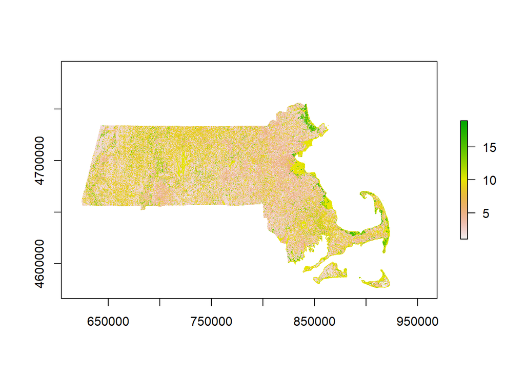

```r
# Plot to look at data
plot(lulc2016)
```

**Reclassify map into fewer land cover categories**

```r
setwd(path.GIS)
classification <- read.csv("Land_Cover_Reclass.csv")
head(classification)
```

```
##   VALUE                      COVERNAME NEW_VALUE NEW_CVR_NM
## 1     1                    Scrub/Shrub         5      Other
## 2     2               Deciduous Forest         1     Forest
## 3     3    Palustrine Forested Wetland         4    Wetland
## 4     4           Developed Open Space         2  Developed
## 5     5                     Impervious         2  Developed
## 6     6 Palustrine Scrub/Shrub Wetland         4    Wetland
```

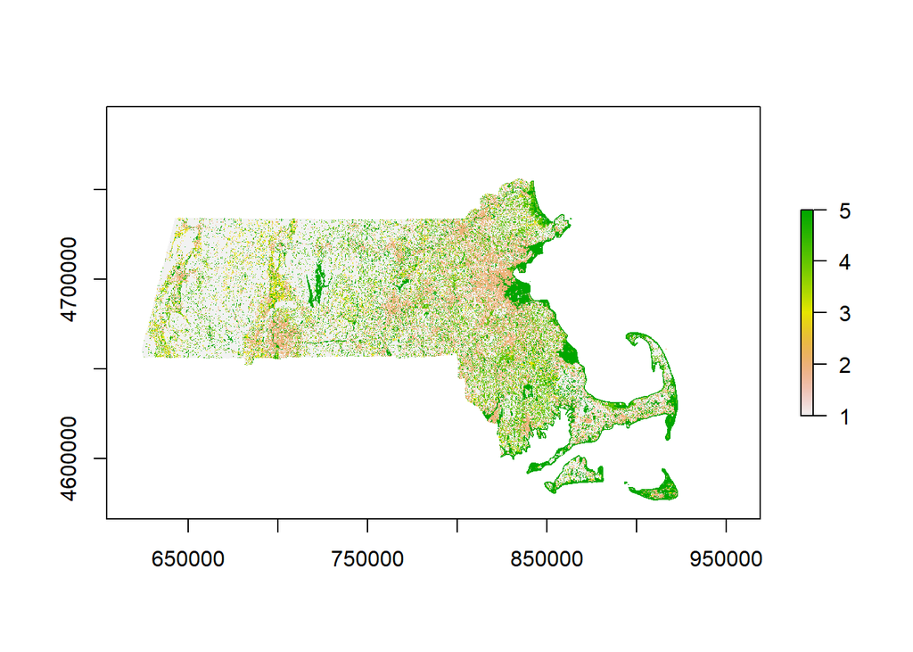

```r
class <- as.matrix(classification[,c(1,3)])
land_sub <- reclassify(lulc2016, rcl = class)
plot(land_sub)
```

**Create a data frame**

```r
data <- data.frame()
```

**List All MCP Files** This allows you to pull in all of the file names from one file folder. It is important to note that this is not the data itself, just the names of the files in the folder.

```r
setwd(path.mcp)
file.list <- list.files(pattern = "\\.shp$", full.names = FALSE)
file.list
```

```
##   [1] "Allison2013.shp"        "Allison2014.shp"        "Amy2012.shp"
##   [4] "August2017.shp"         "August2018.shp"         "BabyP2021.shp"
##   [7] "BigPrescott2015.shp"    "BigPrescott2016.shp"    "BigPrescott2017.shp"
##  [10] "Bittersweet2017.shp"    "BlackHawk2020.shp"      "BlueMeadow2020.shp"
##  [13] "Bonnie2012.shp"         "Bonnie2013.shp"         "Bonnie2015.shp"
##  [16] "Brimfield2013.shp"      "Brimfield2014.shp"      "Brimfield2015.shp"
##  [19] "Broadbrook2014.shp"     "Broadbrook2015.shp"     "Broadbrook2016.shp"
##  [22] "Byrne2018.shp"          "Byrne2019.shp"          "Candace2012.shp"
##  [25] "Candace2013.shp"        "Candace2014.shp"        "Cascade2017.shp"
##  [28] "Cascade2018.shp"        "Coldbrook2013.shp"      "Coldbrook2015.shp"
##  [31] "Coldbrook2016.shp"      "Deck2020.shp"           "Deck2021.shp"
##  [34] "DRF349_2012.shp"        "DRF349_2013.shp"        "Emily2016.shp"
##  [37] "Emily2017.shp"          "Fairfield2018.shp"      "Fairfield2020.shp"
##  [40] "Fairfield2021.shp"      "Fitz2013.shp"           "Fitz2014.shp"
##  [43] "Fitz2015.shp"           "Fitz2016.shp"           "Ginger2017.shp"
```

[output cut: 33 more lines]

```r
for (i in 1:length(file.list)){
# Calling In MCP Data
setwd(path.mcp)
# Defining the name of the bear from the base name of the each file in your list
bear <- basename(file.list[i])
# Using gsub will delete the file extension from the name
bear <- gsub('.shp', '', bear)
mcp <- read_sf(paste0(file.list[i], sep=''))

# Convert
mcp <- sf:::as_Spatial(mcp$geometry)

# Extract values of raster cells within polygon
raster_values <- raster::extract(land_sub, mcp)

# Convert raster values to raster layer
raster_values <- unlist(raster_values)

# Remove any values of na
raster_values <- na.omit(raster_values)

# Calculate the percent of impervious surface (raster value = 5) plus developed open space (raster value = 4)
Percent_Impervious <- (length(raster_values[(raster_values == 5)|(raster_values == 4)]))/(length(raster_values))*100


output = c(bear, Percent_Impervious)
data = rbind(data, output)
colnames (data) <- c("Bear", "Percent_Developed")
}
```

**Make sure that the columns are the correct class**

```r
# Copy column and remove last 4 digits (Year)
data$name <- substr(data$Bear, 1, nchar(data$Bear) - 4)

data$name <- as.character(data$name)

data$Percent_Developed <- as.numeric(data$Percent_Developed)
```

**Save** Save this information as an excel in order to bring in later.

```r
path.save <- "C:/Users/jessi/University of Massachusetts/Jessica-BearProject - General/Final Data/Bear Information"
setwd(path.save)
write_xlsx(data, "C:/Users/jessi/University of Massachusetts/Jessica-BearProject - General/Final Data/Bear Information/Percent_Developed.xlsx")
```

### Percent Area Covered by Building Structures

I calculated the percent area of building structures within a buffer of 100 meters around each point. The size of the buffer was determined by using the average step length for the 45-minute interval as the diameter for the buffer. The centroid of each of the building structures were extracted and then spatially joined to the buffered points.

**Libraries** Make sure to install and pull in the libraries you need in order for your code functions to work.

```r
library(rgdal)
library(raster)
library(sf)
library(adehabitatHR)
library(adehabitatHS)
library(reshape2)
library(dplyr)
```

**Set Paths** Set the path pick the file folder to pull in your data * It will be different based on where your data is stored

```r
path.root <- "C:/Users/jessi/University of Massachusetts/Jessica-BearProject - General/Final Data"
path.data <- paste(path.root, "/Combined Data/Combined, Clipped, Near", sep = "")
path.mcp <- paste(path.root, "/MCPs", sep = "")
path.GIS <- paste(path.root, "/GIS Layers", sep = "")
path.save <- paste(path.root, "/Combined Data/Combined, Clipped, Near, Percent Str", sep = "")
```

**Bring in the building structures layer**

```r
# Read building structures polygon shapefile
setwd(path.GIS)
bld_str <- st_read("building_structures.shp")
# Check Class and CRS
class(bld_str)
```

```
## [1] "sf"         "data.frame"
```

```r
crs(bld_str)
```

```
## [1] "PROJCRS[\"WGS 84 / UTM zone 18N\",\n    BASEGEOGCRS[\"WGS 84\",\n        DATUM[\"World Geodetic System 1984\",\n            ELLIPSOID[\"WGS 84\",6378137,298.257223563,\n                LENGTHUNIT[\"metre\",1]]],\n        PRIMEM[\"Greenwich\",0,\n            ANGLEUNIT[\"degree\",0.01745329251…
```

**Find the centroid of each building polygon**

```r
# Extract centroids and convert to points
bld_str_points <- st_centroid(bld_str)
```

**Bring In Use and Available Point Data**

```r
setwd(path.data)
# Use Points
use_data <- read_sf("Use_Points.shp")
# Available Points
avail_data <- read_sf("Available_Points.shp")
```

**Create buffers for use and availability each point** Make sure there are the same amount of buffers as there are points. Add a FID to each buffer.

```r
# Buffer the use location point by 100 meters
use_buffers <- st_buffer(use_data, dist = 100)
# Check to make sure there are the same amount of buffers as points
nrow(use_data)
```

```
## [1] 597646
```

```r
nrow(use_buffers)
```

```
## [1] 597646
```

```r
# Add buffer FID
use_buffers$Buffer_FID <- 1:nrow(use_buffers)
print(use_buffers$Buffer_FID)
```

[output not shown]

[output cut: 8320 more lines]

```r
# Buffer the available location point by 100 meters
avail_buffers <- st_buffer(avail_data, dist = 100)
# Check to make sure there are the same amount of buffers as points
nrow(avail_data)
```

```
## [1] 1420828
```

```r
nrow(avail_buffers)
```

```
## [1] 1420828
```

```r
# Add Buffer FID
avail_buffers$Buffer_FID <- 1:nrow(avail_buffers)
```

**Join the use data and the building structure centroid points** The area for the building structures is still attached to these points as SHAPE_Area.

```r
# Perform a spatial join between `use_buffers` and `bld_str_points`
joined_use <- st_join(use_buffers, bld_str_points)
head(joined_use)
```

```
## Simple feature collection with 6 features and 30 fields
## Geometry type: POLYGON
## Dimension:     XY
## Bounding box:  xmin: 694777 ymin: 4690401 xmax: 695065.2 ymax: 4690653
## Projected CRS: WGS 84 / UTM zone 18N
## # A tibble: 6 × 31
##   bear       name  br_nmbr  year cb_stts GPS_F_T GPS_F_A GPS_Dlt season NEAR_FID
##   <chr>      <chr>   <dbl> <dbl> <chr>   <chr>   <chr>     <dbl> <chr>     <dbl>
## 1 Allison20… Alli…     298  2013 newborn 2013-0… Succee…     2.8 Spring   507629
## 2 Allison20… Alli…     298  2013 newborn 2013-0… Succee…     2.8 Spring   507629
## 3 Allison20… Alli…     298  2013 newborn 2013-0… Resolv…     1.8 Spring   556874
## 4 Allison20… Alli…     298  2013 newborn 2013-0… Resolv…     1.8 Spring   556874
## 5 Allison20… Alli…     298  2013 newborn 2013-0… Resolv…     2.2 Spring   507629
## 6 Allison20… Alli…     298  2013 newborn 2013-0… Resolv…     2.2 Spring   507629
## # ℹ 21 more variables: NEAR_DIST <dbl>, geometry <POLYGON [m]>,
## #   Buffer_FID <int>, STRUCT_ID <chr>, SOURCE <chr>, SOURCETYPE <chr>,
## #   SOURCEDATE <dbl>, SOURCEDATA <chr>, MOVED <chr>, AREA_SQ_FT <dbl>,
## #   TOWN_ID <int>, TOWN_ID2 <int>, TOWN_ID3 <int>, LOCAL_ID <chr>,
## #   ARCHIVED <chr>, ARCHIVEDAT <dbl>, EDIT_DATE <chr>, EDIT_BY <chr>,
## #   COMMENTS <chr>, SHAPE_Leng <dbl>, SHAPE_Area <dbl>
```

**Turn the NAs to 0 for SHAPE_Area. This will allow us to summarize area of building structures in each buffer even if there is no building in the buffer.**

```r
joined_use$SHAPE_Area[is.na(joined_use$SHAPE_Area)] <- 0
```

**Sum the area if the building structures by the Buffer ID. This will add up all of the building structures area within each buffer.**

```r
summary_use <- aggregate(SHAPE_Area ~ Buffer_FID, data = joined_use, FUN = sum)
head(summary_use)
```

```
##   Buffer_FID SHAPE_Area
## 1          1  173.01415
## 2          2   72.35870
## 3          3  173.01415
## 4          4   72.35870
## 5          5   72.35870
## 6          6   14.98871
```

**Calculate the percentage of building structure in each buffer** Divide the building structures area by the area of the buffer (the area of a circle with a 100 m radius is 31415.93) then multiply by 100

```r
summary_use$Percent_Bld_Str <- ((summary_use$SHAPE_Area/31415.93)*100)
```

**Add the percentage of building structure to the Use data**

```r
use_data <- cbind(use_data, summary_use$Percent_Bld_Str)
colnames(use_data)[which(names(use_data) == "summary_use.Percent_Bld_Str")] <-"Percent_Bld_Str"
```

**Export as a Shapefile**

```r
setwd(path.save)
st_write(use_data, "Use_Points", driver = "ESRI Shapefile", append=FALSE)
```

```
## Deleting layer `Use_Points' using driver `ESRI Shapefile'
## Writing layer `Use_Points' to data source `Use_Points' using driver `ESRI Shapefile'
## Writing 597646 features with 12 fields and geometry type Point.
```

**Repeat for available points data** Join the available data and the building structure centroid points. The area for the building structures is still attached to these points as SHAPE_Area.

```r
# Perform a spatial join between `use_buffers` and `bld_str_points`
joined_avail <- st_join(avail_buffers, bld_str_points)
head(joined_avail)
```

```
## Simple feature collection with 6 features and 26 fields
## Geometry type: POLYGON
## Dimension:     XY
## Bounding box:  xmin: 690277.1 ymin: 4692039 xmax: 695212.9 ymax: 4696568
## Projected CRS: WGS 84 / UTM zone 18N
## # A tibble: 6 × 27
##   bear  name  br_nmbr  year cb_stts NEAR_FID NEAR_DIST                  geometry
##   <chr> <chr>   <dbl> <dbl> <chr>      <dbl>     <dbl>             <POLYGON [m]>
## 1 Alli… Alli…     298  2013 newborn  1192438     341.  ((694457.5 4695597, 6944…
## 2 Alli… Alli…     298  2013 newborn   610724     171.  ((695212.9 4692139, 6952…
## 3 Alli… Alli…     298  2013 newborn  1987924      48.8 ((690477.1 4694812, 6904…
## 4 Alli… Alli…     298  2013 newborn   235117     166.  ((692365.6 4692227, 6923…
## 5 Alli… Alli…     298  2013 newborn  1614425     503.  ((694399.4 4696468, 6943…
## 6 Alli… Alli…     298  2013 newborn   218748     182.  ((693644 4693999, 693643…
## # ℹ 19 more variables: Buffer_FID <int>, STRUCT_ID <chr>, SOURCE <chr>,
## #   SOURCETYPE <chr>, SOURCEDATE <dbl>, SOURCEDATA <chr>, MOVED <chr>,
## #   AREA_SQ_FT <dbl>, TOWN_ID <int>, TOWN_ID2 <int>, TOWN_ID3 <int>,
## #   LOCAL_ID <chr>, ARCHIVED <chr>, ARCHIVEDAT <dbl>, EDIT_DATE <chr>,
## #   EDIT_BY <chr>, COMMENTS <chr>, SHAPE_Leng <dbl>, SHAPE_Area <dbl>
```

**Turn the NAs to 0 for SHAPE_Area** This will allow us to summarize area of building structures in each buffer even if there is no building in the buffer.

```r
joined_avail$SHAPE_Area[is.na(joined_avail$SHAPE_Area)] <- 0
```

**Sum the area if the building structures by the Buffer ID** This will add up all of the building structures area within each buffer.

```r
summary_avail <- aggregate(SHAPE_Area ~ Buffer_FID, data = joined_avail, FUN = sum)
head(summary_avail)
```

```
##   Buffer_FID SHAPE_Area
## 1          1    0.00000
## 2          2    0.00000
## 3          3   79.65835
## 4          4    0.00000
## 5          5    0.00000
## 6          6    0.00000
```

**Calculate the percentage of building structure in each buffer** Divide the building structures area by the area of the buffer (the area of a circle with a 100 m radius is 31415.93) then multiply by 100

```r
summary_avail$Percent_Bld_Str <- ((summary_avail$SHAPE_Area/31415.93)*100)
```

**Add the percentage of building structure to the avail data**

```r
avail_data <- cbind(avail_data, summary_avail$Percent_Bld_Str)
colnames(avail_data)
```

```
## [1] "bear"                          "name"
## [3] "br_nmbr"                       "year"
## [5] "cb_stts"                       "NEAR_FID"
## [7] "NEAR_DIST"                     "summary_avail.Percent_Bld_Str"
## [9] "geometry"
```

```r
colnames(avail_data)[which(names(avail_data) == "summary_avail.Percent_Bld_Str")] <-"Percent_Bld_Str"
```

**Export as a Shapefile**

```r
setwd(path.save)
st_write(avail_data, "Avail_Points", driver = "ESRI Shapefile", append=FALSE)
```

```
## Deleting layer `Avail_Points' using driver `ESRI Shapefile'
## Writing layer `Avail_Points' to data source
##   `Avail_Points' using driver `ESRI Shapefile'
## Writing 1420828 features with 8 fields and geometry type Point.
```

### Land Use

**Set Paths** Set the path pick the file folder to pull in your data. It will be different based on where your data is stored

```r
path.root <- "C:/Users/jessi/University of Massachusetts/Jessica-BearProject - General/Final Data"
path.use.data <- paste(path.root, "/Combined Data/Combined, Clipped, Near, Percent Str/Use_Points", sep = "")
path.avail.data <- paste(path.root, "/Combined Data/Combined, Clipped, Near, Percent Str/Avail_Points", sep = "")
path.GIS <- paste(path.root, "/GIS Layers", sep = "")
path.save <- paste(path.root, "/Final Data", sep = "")
```

**Libraries** Make sure to install and pull in the libraries you need in order for your code functions to work

```r
library(readr)
library(raster)
library(rgdal)
library(sf)
library(dplyr)
library(writexl)
```

**Pull in the Use Data shapefile and available data shapefile**

```r
# Use Data
setwd(path.use.data)
use_points <- st_read("Use_Points.shp")
# Available Data
setwd(path.avail.data)
avail_points <- st_read("Avail_Points.shp")
```

**Bring in the land cover 2016 data**

```r
# Set Path
setwd(path.GIS)
lulc2016 <-raster("LULC2016.tif")
```

**Examine the raster data**

```r
# Check the coordinate reference system
print(crs(lulc2016))
```

```
## Coordinate Reference System:
## Deprecated Proj.4 representation:
##  +proj=utm +zone=18 +datum=WGS84 +units=m +no_defs
## WKT2 2019 representation:
## PROJCRS["unknown",
##     BASEGEOGCRS["unknown",
##         DATUM["World Geodetic System 1984",
##             ELLIPSOID["WGS 84",6378137,298.257223563,
##                 LENGTHUNIT["metre",1]],
##             ID["EPSG",6326]],
##         PRIMEM["Greenwich",0,
##             ANGLEUNIT["degree",0.0174532925199433],
##             ID["EPSG",8901]]],
##     CONVERSION["UTM zone 18N",
##         METHOD["Transverse Mercator",
##             ID["EPSG",9807]],
##         PARAMETER["Latitude of natural origin",0,
##             ANGLEUNIT["degree",0.0174532925199433],
##             ID["EPSG",8801]],
##         PARAMETER["Longitude of natural origin",-75,
##             ANGLEUNIT["degree",0.0174532925199433],
##             ID["EPSG",8802]],
##         PARAMETER["Scale factor at natural origin",0.9996,
##             SCALEUNIT["unity",1],
##             ID["EPSG",8805]],
##         PARAMETER["False easting",500000,
##             LENGTHUNIT["metre",1],
##             ID["EPSG",8806]],
##         PARAMETER["False northing",0,
##             LENGTHUNIT["metre",1],
##             ID["EPSG",8807]],
##         ID["EPSG",16018]],
##     CS[Cartesian,2],
##         AXIS["(E)",east,
##             ORDER[1],
##             LENGTHUNIT["metre",1,
##                 ID["EPSG",9001]]],
##         AXIS["(N)",north,
##             ORDER[2],
##             LENGTHUNIT["metre",1,
##                 ID["EPSG",9001]]]]
```

```r
# Define the projection string for UTM Zone 18
UTM18 <- CRS("+init=epsg:32618")

# Define land use coordinate system
crs(lulc2016) <- UTM18
print(crs(lulc2016))
```

```
## Coordinate Reference System:
## Deprecated Proj.4 representation:
##  +proj=utm +zone=18 +datum=WGS84 +units=m +no_defs
## WKT2 2019 representation:
## PROJCRS["WGS 84 / UTM zone 18N",
##     BASEGEOGCRS["WGS 84",
##         ENSEMBLE["World Geodetic System 1984 ensemble",
##             MEMBER["World Geodetic System 1984 (Transit)"],
##             MEMBER["World Geodetic System 1984 (G730)"],
##             MEMBER["World Geodetic System 1984 (G873)"],
##             MEMBER["World Geodetic System 1984 (G1150)"],
##             MEMBER["World Geodetic System 1984 (G1674)"],
##             MEMBER["World Geodetic System 1984 (G1762)"],
##             MEMBER["World Geodetic System 1984 (G2139)"],
##             ELLIPSOID["WGS 84",6378137,298.257223563,
##                 LENGTHUNIT["metre",1]],
##             ENSEMBLEACCURACY[2.0]],
##         PRIMEM["Greenwich",0,
##             ANGLEUNIT["degree",0.0174532925199433]],
##         ID["EPSG",4326]],
##     CONVERSION["UTM zone 18N",
##         METHOD["Transverse Mercator",
##             ID["EPSG",9807]],
##         PARAMETER["Latitude of natural origin",0,
##             ANGLEUNIT["degree",0.0174532925199433],
##             ID["EPSG",8801]],
##         PARAMETER["Longitude of natural origin",-75,
##             ANGLEUNIT["degree",0.0174532925199433],
##             ID["EPSG",8802]],
##         PARAMETER["Scale factor at natural origin",0.9996,
##             SCALEUNIT["unity",1],
##             ID["EPSG",8805]],
##         PARAMETER["False easting",500000,
##             LENGTHUNIT["metre",1],
##             ID["EPSG",8806]],
##         PARAMETER["False northing",0,
##             LENGTHUNIT["metre",1],
##             ID["EPSG",8807]],
##         ID["EPSG",16018]],
##     CS[Cartesian,2],
##         AXIS["(E)",east,
##             ORDER[1],
##             LENGTHUNIT["metre",1,
##                 ID["EPSG",9001]]],
##         AXIS["(N)",north,
##             ORDER[2],
##             LENGTHUNIT["metre",1,
##                 ID["EPSG",9001]]],
##     USAGE[
##         SCOPE["unknown"],
##         AREA["Between 78°W and 72°W, northern hemisphere between equator and 84°N, onshore and offshore. Bahamas. Canada - Nunavut; Ontario; Quebec. Colombia. Cuba. Ecuador. Greenland. Haiti. Jamaica. Panama. Turks and Caicos Islands. United States (USA). Venezuela."],
##         BBOX[0,-78,84,-72]]]
```

**Bring in file that cintains new land cover variables and classifications**

```r
setwd(path.GIS)
# This file has the new land cover variable and description
classification_cover <- read.csv("Land_Cover_Reclass.csv")
head(classification_cover)
```

```
##   VALUE                      COVERNAME NEW_VALUE NEW_CVR_NM
## 1     1                    Scrub/Shrub         5      Other
## 2     2               Deciduous Forest         1     Forest
## 3     3    Palustrine Forested Wetland         4    Wetland
## 4     4           Developed Open Space         2  Developed
## 5     5                     Impervious         2  Developed
## 6     6 Palustrine Scrub/Shrub Wetland         4    Wetland
```

**Reclassify map into fewer land cover categories**

```r
class <- as.matrix(classification_cover[,c(1,3)])
land_cover <- reclassify(lulc2016, rcl = class)
```

**Buffer the quabbin and get rid of available points in the quabbin to run again and see if there is a major difference in selection**

```r
# Read in quabbin shapefile
setwd(path.GIS)
quabbin <- read_sf("quabbin.shp")
crs(quabbin)
```

```
## [1] "PROJCRS[\"WGS 84 / UTM zone 18N\",\n    BASEGEOGCRS[\"WGS 84\",\n        DATUM[\"World Geodetic System 1984\",\n            ELLIPSOID[\"WGS 84\",6378137,298.257223563,\n                LENGTHUNIT[\"metre\",1]]],\n        PRIMEM[\"Greenwich\",0,\n            ANGLEUNIT[\"degree\",0.01745329251…
```

```r
#Buffer by -50 meters, this goes 50 meter into the quabbin from the shore
# Add a -50 meter buffer
buffer <- st_buffer(quabbin, dist = -50)


# Change back to spatial data frame
buffer <- st_as_sf(buffer)

# Assign IDs to each point
avail_points$ID <- 1:nrow(avail_points)


# Select all of the points inside the quabbin, we will get rid of these
remove_points <- st_join(buffer, avail_points)
nrow(remove_points)
```

```
## [1] 12862
```

```r
# Remove the points inside the quabbin and make sure the numbers are adding up correctly to ensure we aren't making a major mistake
# Remove points that were joined with the polygon
filtered_points <- avail_points[!avail_points$ID %in% remove_points$ID, ]
nrow(filtered_points)
```

```
## [1] 1407966
```

```r
# Check
nrow(avail_points)
```

```
## [1] 1420828
```

```r
nrow(filtered_points)+nrow(remove_points)
```

```
## [1] 1420828
```

**Extract Land Cover Data to Points** Remember the use_data already has all of the bear information, distance to nearest structure, and percent building structure for each point.

```r
use <- extract(land_cover, use_points)
avail <- extract(land_cover, filtered_points)
```

**Convert matrices into dataframes**

```r
# Convert the matrix or array into a data frame
use <- as.data.frame(use)
head(use)
```

```
##   use
## 1   3
## 2   1
## 3   3
## 4   1
## 5   1
## 6   1
```

```r
avail <- as.data.frame(avail)
head(avail)
```

```
##   avail
## 1     1
## 2     4
## 3     2
## 4     1
## 5     1
## 6     3
```

**Add Extracted Data to the Use and Available Data Dataframes** This extracted data now has land cover code, distance to nearest structure, and percent building structure. Change the column names to be more clear.

```r
# Combine
use <- data.frame(cbind(use_points, use))
head(use)
```

```
##          bear    name br_nmbr year cb_stts                 GPS_F_T
## 1 Allison2013 Allison     298 2013 newborn 2013-04-03 14:46:23 EDT
## 2 Allison2013 Allison     298 2013 newborn 2013-04-03 17:45:33 EDT
## 3 Allison2013 Allison     298 2013 newborn 2013-04-03 20:00:27 EDT
## 4 Allison2013 Allison     298 2013 newborn 2013-04-04 13:15:33 EDT
## 5 Allison2013 Allison     298 2013 newborn 2013-04-04 14:00:55 EDT
## 6 Allison2013 Allison     298 2013 newborn 2013-04-04 14:45:54 EDT
##          GPS_F_A GPS_Dlt season NEAR_FI  NEAR_DI    Prc_B_S use
## 1 Succeeded (3D)     2.8 Spring  507629 58.44524 0.55072109   3
## 2   Resolved QFP     1.8 Spring  556874 15.18350 0.23032486   1
## 3   Resolved QFP     2.2 Spring  507629 64.14620 0.55072109   3
## 4   Resolved QFP     2.4 Spring  556874 23.32849 0.23032486   1
## 5   Resolved QFP     2.9 Spring  493250 26.99456 0.23032486   1
## 6 Succeeded (3D)     2.7 Spring  493250 50.82851 0.04771053   1
##                   geometry
## 1 POINT (694965.2 4690553)
## 2   POINT (694877 4690501)
## 3 POINT (694955.6 4690553)
## 4 POINT (694850.6 4690531)
## 5   POINT (694798 4690498)
## 6 POINT (694773.8 4690512)
```

```r
# Change column names
names(use)[names(use) == 'Prc_B_S'] <- 'perc_bld_str'
names(use)[names(use) == 'NEAR_DI'] <- 'dis2str'
names(use)[names(use) == 'use'] <- 'landcover'
colnames(use)
```

```
##  [1] "bear"         "name"         "br_nmbr"      "year"         "cb_stts"
##  [6] "GPS_F_T"      "GPS_F_A"      "GPS_Dlt"      "season"       "NEAR_FI"
## [11] "dis2str"      "perc_bld_str" "landcover"    "geometry"
```

```r
# Combine
avail <- data.frame(cbind(filtered_points, avail))
head(avail)
```

```
##          bear    name br_nmbr year cb_stts NEAR_FI   NEAR_DI   Prc_B_S ID avail
## 1 Allison2013 Allison     298 2013 newborn 1192438 340.61424 0.0000000  1     1
## 2 Allison2013 Allison     298 2013 newborn  610724 170.81000 0.0000000  2     4
## 3 Allison2013 Allison     298 2013 newborn 1987924  48.75756 0.2535604  3     2
## 4 Allison2013 Allison     298 2013 newborn  235117 166.02121 0.0000000  4     1
## 5 Allison2013 Allison     298 2013 newborn 1614425 503.10822 0.0000000  5     1
## 6 Allison2013 Allison     298 2013 newborn  218748 182.39786 0.0000000  6     3
##                   geometry
## 1 POINT (694357.5 4695597)
## 2 POINT (695112.9 4692139)
## 3 POINT (690377.1 4694812)
## 4 POINT (692265.6 4692227)
## 5 POINT (694299.4 4696468)
## 6   POINT (693544 4693999)
```

```r
# Change Column names
names(avail)[names(avail) == 'Prc_B_S'] <- 'perc_bld_str'
names(avail)[names(avail) == 'NEAR_DI'] <- 'dis2str'
names(avail)[names(avail) == 'avail'] <- 'landcover'
colnames(avail)
```

```
##  [1] "bear"         "name"         "br_nmbr"      "year"         "cb_stts"
##  [6] "NEAR_FI"      "dis2str"      "perc_bld_str" "ID"           "landcover"
## [11] "geometry"
```

**Check to see how many and what points have no land cover data in use and available**

```r
# Use
use_before <- nrow(use)
# Remove NAs
use <- use[!is.na(use$landcover),]
# Number of rows lost to NA
use_before-nrow(use)
```

```
## [1] 12
```

```r
# Available
avail_before <- nrow(avail)
# Remove NAs
avail <- avail[!is.na(avail$landcover),]
# Number of rows lost to NA
avail_before-nrow(avail)
```

```
## [1] 25
```

**Change the reproductive status “unknown” rows for broadbrook2014 to “none”**

```r
# Use
# Conditions
condition1 <- use$bear == "Broadbrook2014"
condition2 <- use$cb_stts == "unknown"

# Changing row value based on conditions
use$cb_stts[condition1 & condition2] <- "none"

# Available
# Conditions
condition1 <- avail$bear == "Broadbrook2014"
condition2 <- avail$cb_stts == "unknown"

# Changing row value based on conditions
avail$cb_stts[condition1 & condition2] <- "none"
```

**Change the reproductive status “unknown” rows for May2013 to “none”**

```r
# Use
# Conditions
condition1 <- use$bear == "May2013"
condition2 <- use$cb_stts == "unknown"

# Changing row value based on conditions
use$cb_stts[condition1 & condition2] <- "none"

# Available
# Conditions
condition1 <- avail$bear == "May2013"
condition2 <- avail$cb_stts == "unknown"

# Changing row value based on conditions
avail$cb_stts[condition1 & condition2] <- "none"
```

**Examine count of use points by seasons**

```r
seasons_sum <- use %>%
  group_by(season) %>%
  summarise(count = n())
head(seasons_sum)
```

```
## # A tibble: 3 × 2
##   season  count
##   <chr>   <int>
## 1 Fall   233772
## 2 Spring 204591
## 3 Summer 159271
```

**Remove NAs in data** There were no NAs but better to do this step anyways

```r
# Remove NAs
use <- use[!is.na(use$season),]
```

**Save**

```r
# Set the path to where you want your outputs saved
setwd(path.save)

# Save Use Points Shapefile
st_write(use, "Use_Points", driver = "ESRI Shapefile", append=FALSE)
```

```
## Deleting layer `Use_Points' using driver `ESRI Shapefile'
## Writing layer `Use_Points' to data source `Use_Points' using driver `ESRI Shapefile'
## Writing 597634 features with 13 fields and geometry type Point.
```

```r
# Save Available Points Shapefile
st_write(avail, "Available_Points", driver = "ESRI Shapefile", append=FALSE)
```

```
## Deleting layer `Available_Points' using driver `ESRI Shapefile'
## Writing layer `Available_Points' to data source
##   `Available_Points' using driver `ESRI Shapefile'
## Writing 1407941 features with 10 fields and geometry type Point.
```

## Models

### Correlation, Multicollinearity, and AICs

**Libraries** Make sure to install and pull in the libraries you need in order for your code functions to work

```r
library(terra)
library(raster)
library(sf)
library(adehabitatHR)
library(adehabitatHS)
library(reshape2)
library(dplyr)
library(writexl)
library(readxl)
```

**Set Paths** Set the path pick the file folder to pull in your data. It will be different based on where your data is stored

```r
path.root <- "C:/Users/jessi/University of Massachusetts/Jessica-BearProject - General/Final Data"
path.use.data <- paste(path.root, "/Final Data/Use_Points", sep = "")
path.avail.data <- paste(path.root, "/Final Data/Available_Points", sep = "")
path.gradient <- paste(path.root, "/Bear Information", sep = "")
```

**Bring In Use and Available Point Data** This data contains the bear information and distance to nearest structure

```r
# Use Points
setwd(path.use.data)
use_data <- read_sf("Use_Points.shp")
# Available Points
setwd(path.avail.data)
avail_data <- read_sf("Available_Points.shp")
```

**Bring in the information that is the percent developed in the home range** The value we are using for urbanization

```r
setwd(path.gradient)
gradient <- read_excel("Percent_Developed.xlsx")
gradient <- gradient[ ,1:2]
colnames(gradient) <- c("bear", "HR_perc_dev")
```

**Add the urbanization value to the points data sets**

```r
use_data <- merge(use_data, gradient, by = "bear", all = TRUE)
avail_data <- merge(avail_data, gradient, by = "bear", all = TRUE)
```

**Convert the reproductive status of “yearling” to “none”** This will give us 2 options for reproductive status “none” and “newborn”

```r
# Change row values from "yearling" to "none"
use_data$cb_stts <- ifelse(use_data$cb_stts == "yearling", "none", use_data$cb_stts)
avail_data$cb_stts <- ifelse(avail_data$cb_stts == "yearling", "none", avail_data$cb_stts)
```

**Check the column names to see what data we have** Note that the available data does not have season.

```r
colnames(use_data)
```

```
##  [1] "bear"        "name"        "br_nmbr"     "year"        "cb_stts"
##  [6] "GPS_F_T"     "GPS_F_A"     "GPS_Dlt"     "season"      "NEAR_FI"
## [11] "dis2str"     "prc_bl_"     "landcvr"     "HR_perc_dev" "geometry"
```

```r
colnames(avail_data)
```

```
##  [1] "bear"        "name"        "br_nmbr"     "year"        "cb_stts"
##  [6] "NEAR_FI"     "dis2str"     "prc_bl_"     "ID"          "landcvr"
## [11] "HR_perc_dev" "geometry"
```

**Create a dataframe to run in model** This final data frame will be combined use and available points. The bear number will be used as the identifier for each point. The covariates will include land cover, nearest distance to structure, percent building structure, and use/availability as a binomial (use = 1, available = 0)

```r
# Subset the data by bear number and covariates
# br_nmbr is the bear number / bear ID
# dis2str is the distance to nearest structure
# landcvr is the reclassified lad cover
# prc_bl_ is the percent building structure in the buffered point
use <- subset(use_data, select = c(br_nmbr, year, cb_stts, season, landcvr, dis2str, prc_bl_, HR_perc_dev))
avail <- subset(avail_data, select = c(br_nmbr, year, cb_stts, landcvr, dis2str, prc_bl_, HR_perc_dev))
```

**Assign random seasons to availability points** This is necessary when running a glm because all columns must be the same between use and available points

```r
avail$season <- rep(c("Summer", "Fall", "Spring"), length.out = nrow(avail))
# Change the order of columns to match use.2
avail <- avail[, c("br_nmbr", "year", "cb_stts", "season", "landcvr", "dis2str", "prc_bl_", "HR_perc_dev")]
```

**Combine the use and available data into one data frame**

```r
# Create data frame
# This adds use as a binomial
use.cov <- data.frame(use[,1:8], use = 1)
back.cov <- data.frame(avail[,1:8], use = 0)
# Combine the use and available points data to create one large dataframe
all.cov <- data.frame(rbind(use.cov, back.cov))
# Check the class of the landcover
class(all.cov$landcvr)
```

```
## [1] "numeric"
```

```r
# Convert to factor
all.cov$landcvr <- as.factor(all.cov$landcvr)
class(all.cov$landcvr)
```

```
## [1] "factor"
```

```r
# Check the columns of the dataframe
colnames(all.cov)
```

```
##  [1] "br_nmbr"     "year"        "cb_stts"     "season"      "landcvr"
##  [6] "dis2str"     "prc_bl_"     "HR_perc_dev" "geometry"    "use"
```

**Correlation refers to the linear relationship between 2 variables** Can be evaluated using correlation coefficient. A value of r close to -1: means that there is negative correlation between the variables (when one increases the other decreases and vice versa). A value of r close to 0: indicates that the 2 variables are not correlated (no linear relationship exists between them). A value of r close to 1: indicates a positive linear relationship between the 2 variables (when one increases, so does the other).

```r
# All varibables must be numeric to run cor()
all.cov$landcvr <- as.numeric(all.cov$landcvr)
class(all.cov$landcvr)
```

```
## [1] "numeric"
```

```r
class(all.cov$dis2str)
```

```
## [1] "numeric"
```

```r
class(all.cov$prc_bl_)
```

```
## [1] "numeric"
```

```r
cor(all.cov[, 5:7])
```

```
##             landcvr     dis2str    prc_bl_
## landcvr  1.00000000 -0.09071297  0.0118172
## dis2str -0.09071297  1.00000000 -0.1859792
## prc_bl_  0.01181720 -0.18597922  1.0000000
```

```r
# Based off these values, there is not significant correlation between any 2 variables, so all variables can be used in the model

all.cov$landcvr <- as.factor(all.cov$landcvr)
```

**Collinearity** refers to a problem when running a regression model where 2 or more independent variables (a.k.a. predictors) have a strong linear relationship. Can be evaluated using correlation matrix or VIF. **Multicollinearity** is a special case of collinearity where a strong linear relationship exists between 3 or more independent variables even if no pair of variables has a high correlation. Can be evaluated using VIF.

VIF measures the strength of correlation between predictor variables in a model. It takes on a value between 1 and positive infinity. VIF = 1: There is no correlation between a given predictor variable and any other predictor variables in the model. VIF between 1 and 5: There is moderate correlation between a given predictor variable and other predictor variables in the model. VIF > 5: There is severe correlation between a given predictor variable and other predictor variables in the model.

```r
library(car)
# define multiple linear regression model
model_all <- glm(use ~ landcvr + dis2str + prc_bl_, data = all.cov)

#calculate the VIF for each predictor variable in the model
vif(model_all)
```

```
##             GVIF Df GVIF^(1/(2*Df))
## landcvr 1.177305  4        1.020613
## dis2str 1.062156  1        1.030610
## prc_bl_ 1.169948  1        1.081641
```

```r
# Based off these values, there is not multicollinearity, so all variables can be used in the model
```

**Check class of variables**

```r
class(all.cov$use)
```

```
## [1] "numeric"
```

```r
class(all.cov$landcvr)
```

```
## [1] "factor"
```

```r
class(all.cov$dis2str)
```

```
## [1] "numeric"
```

```r
class(all.cov$prc_bl_)
```

```
## [1] "numeric"
```

**Scale the continuous variables in order for the model to run more efficiently**

```r
# Step 1: Identify the columns to scale
columns_to_scale <- c("dis2str", "prc_bl_", "HR_perc_dev")

# Step 2: Subset the data frame
df_subset <- all.cov[, columns_to_scale]

# Step 3: Apply scale() to the subsetted data
scaled_data <- scale(df_subset, center = TRUE, scale = TRUE)

# Step 4: Replace the original columns with scaled values
all.cov[, columns_to_scale] <- scaled_data
```

**Check all data to ensure that they are the correct classes and examine the data in the columns**

```r
head(all.cov)
```

```
##   br_nmbr year cb_stts season landcvr    dis2str    prc_bl_ HR_perc_dev
## 1     298 2013 newborn Spring       3 -0.5057855 -0.1348532   0.6798033
## 2     298 2013 newborn Spring       1 -0.6304520 -0.2366234   0.6798033
## 3     298 2013 newborn Spring       3 -0.4893571 -0.1348532   0.6798033
## 4     298 2013 newborn Spring       1 -0.6069808 -0.2366234   0.6798033
## 5     298 2013 newborn Spring       1 -0.5964163 -0.2366234   0.6798033
## 6     298 2013 newborn Spring       1 -0.5277345 -0.2946287   0.6798033
##                   geometry use
## 1 POINT (694965.2 4690553)   1
## 2   POINT (694877 4690501)   1
## 3 POINT (694955.6 4690553)   1
## 4 POINT (694850.6 4690531)   1
## 5   POINT (694798 4690498)   1
## 6 POINT (694773.8 4690512)   1
```

```r
# Column br_nmbr
class(all.cov$br_nmbr)
```

```
## [1] "numeric"
```

```r
all.cov$br_nmbr <- as.factor(all.cov$br_nmbr)
levels(all.cov$br_nmbr)
```

```
##  [1] "234" "253" "258" "269" "298" "309" "310" "323" "349" "355" "356" "357"
## [13] "370" "373" "376" "388" "391" "393" "395" "403" "404" "406" "414" "424"
## [25] "425" "426" "428" "432" "433" "436" "445" "449" "451" "465" "470" "471"
## [37] "472" "476" "478" "484" "485" "486" "487" "489" "490" "500" "506" "510"
## [49] "512" "514" "515" "516" "518" "528" "529" "536" "544" "548" "549" "553"
## [61] "557" "577"
```

```r
# Column year
class(all.cov$year)
```

```
## [1] "numeric"
```

```r
all.cov$year <- as.factor(all.cov$year)
levels(all.cov$year)
```

```
##  [1] "2012" "2013" "2014" "2015" "2016" "2017" "2018" "2019" "2020" "2021"
```

```r
# Column cb_stts
class(all.cov$cb_stts)
```

```
## [1] "character"
```

```r
all.cov$cb_stts <- as.factor(all.cov$cb_stts)
levels(all.cov$cb_stts)
```

```
## [1] "newborn" "none"
```

```r
# Column season
class(all.cov$season)
```

```
## [1] "character"
```

```r
all.cov$season <- as.factor(all.cov$season)
levels(all.cov$season)
```

```
## [1] "Fall"   "Spring" "Summer"
```

```r
# Column landcvr
class(all.cov$landcvr)
```

```
## [1] "factor"
```

```r
levels(all.cov$landcvr)
```

```
## [1] "1" "2" "3" "4" "5"
```

```r
# Column dis2str
class(all.cov$dis2str)
```

```
## [1] "numeric"
```

```r
# Column prc_bl_
class(all.cov$prc_bl_)
```

```
## [1] "numeric"
```

```r
# Column HR_perc_dev
class(all.cov$HR_perc_dev)
```

```
## [1] "numeric"
```

```r
# Column use
class(all.cov$use)
```

```
## [1] "numeric"
```

```r
# Remove the 'geometry' column from the data frame
all.cov <- all.cov[, -which(names(all.cov) == "geometry")]
head(all.cov)
```

```
##   br_nmbr year cb_stts season landcvr    dis2str    prc_bl_ HR_perc_dev use
## 1     298 2013 newborn Spring       3 -0.5057855 -0.1348532   0.6798033   1
## 2     298 2013 newborn Spring       1 -0.6304520 -0.2366234   0.6798033   1
## 3     298 2013 newborn Spring       3 -0.4893571 -0.1348532   0.6798033   1
## 4     298 2013 newborn Spring       1 -0.6069808 -0.2366234   0.6798033   1
## 5     298 2013 newborn Spring       1 -0.5964163 -0.2366234   0.6798033   1
## 6     298 2013 newborn Spring       1 -0.5277345 -0.2946287   0.6798033   1
```

**Run a base model** to be able to compare model fit with different iterations of models with interactions. Use is the response variable, 0 is the intercept (used here to mean no selection). The fixed effects in the models included land cover, distance to nearest structure, and percent building structure area within a buffered point. Bear number is a random effect to account for variability of behavior among different bears. The family is binomial because the response variable (use) is either 1 or 0.

```r
library(lme4)
# Create a glmerControl object with increased tolerance
control <- glmerControl(optimizer = "Nelder_Mead", optCtrl = list(tol = 0.005))
```

**Run multiple models with different interactions between fixed effects and reproductive status (criterion variable).**

```r
library(lme4)
# GLM with reproductive status
model_1.1 <- glmer(use ~ 0 + landcvr * cb_stts + (1 | br_nmbr), family = binomial, data = all.cov, control = control)
model_1.2 <- glmer(use ~ 0 + landcvr * cb_stts + dis2str * cb_stts + (1 | br_nmbr), family = binomial, data = all.cov, control = control)
model_1.3 <- glmer(use ~ 0 + landcvr * cb_stts + dis2str * cb_stts + prc_bl_ * cb_stts + (1 | br_nmbr), family = binomial, data = all.cov, control = control)
```

**Look at different Akaike’s Information Criterion (AIC) values** to see which models best fit the data.The model with the lowest AIC indicates the model best fit for the data. The delta AIC is a measure of fit of each model compared to the best fit model with a measurement of 0 indicating the model of best fit. In this case, model 1.3 is the best fit.

```r
library(AICcmodavg)
#define list of models
models_repro_status <- list(model_1.1, model_1.2, model_1.3)

#specify model names
mod.names.repro.status <- c("1.1", "1.2", "1.3")

#calculate AIC of each model
aictab(cand.set = models_repro_status, modnames = mod.names.repro.status)
```

```
##
## Model selection based on AICc:
##
##      K    AICc Delta_AICc AICcWt Cum.Wt       LL
## 1.3 15 2050324       0.00      1      1 -1025147
## 1.2 13 2053348    3023.23      0      1 -1026661
## 1.1 11 2054176    3851.24      0      1 -1027077
```

**Save the model**

```r
setwd("C:/Users/jessi/University of Massachusetts/Jessica-BearProject - General/Final Data/Models")

# Save the model to an RDS file
saveRDS(model_1.3, file = "model_1.3.rds")
```

### Final Model

The RSF provides selection estimates that gave information on the change in selection for the predictor values. The selection estimates give the log-odds or selection change for every unit of change of the response variable. The odds ratio is used to compare the odds of habitat attributes being selected based on different variables. An odds ratio close to zero indicates zero selection behavior with use being proportional to availability. If the odds ratio is negative, there is selection against a particular habitat attribute. If the odds ratio is positive, there is selection for a particular habitat attribute.

**Set Paths** Set the path pick the file folder to pull in your data. It will be different based on where your data is stored

```r
path.models <-"C:/Users/jessi/University of Massachusetts/Jessica-BearProject - General/Final Data/Models"
```

**Pull in the model**

```r
setwd(path.models)
# Load the model back from the RDS file
model_1 <- readRDS("model_1.3.rds")
```

**Summarize the model**

```r
model_1_summary <- summary(model_1)
print(model_1_summary)
```

```
## Generalized linear mixed model fit by maximum likelihood (Laplace
##   Approximation) [glmerMod]
##  Family: binomial  ( logit )
## Formula: use ~ 0 + landcvr * cb_stts + dis2str * cb_stts + prc_bl_ * cb_stts +
##     (1 | br_nmbr)
##    Data: all.cov
## Control: control
##
##      AIC      BIC   logLik deviance df.resid
##  2050324  2050512 -1025147  2050294  2005560
##
## Scaled residuals:
##     Min      1Q  Median      3Q     Max
##   -3.74   -0.61   -0.39    0.71 1338.94
##
## Random effects:
##  Groups  Name        Variance Std.Dev.
##  br_nmbr (Intercept) 0.9547   0.9771
## Number of obs: 2005575, groups:  br_nmbr, 62
##
## Fixed effects:
##                       Estimate Std. Error z value Pr(>|z|)
## landcvr1             -0.536239   0.093988  -5.705 1.16e-08 ***
## landcvr2             -1.778262   0.094639 -18.790  < 2e-16 ***
## landcvr3             -1.703828   0.095091 -17.918  < 2e-16 ***
## landcvr4              0.469722   0.094114   4.991 6.01e-07 ***
## landcvr5             -0.851711   0.094392  -9.023  < 2e-16 ***
## cb_sttsnone          -0.188808   0.004622 -40.854  < 2e-16 ***
## dis2str               0.034436   0.002504  13.750  < 2e-16 ***
## prc_bl_              -0.199214   0.004847 -41.101  < 2e-16 ***
## landcvr2:cb_sttsnone  0.302349   0.017160  17.620  < 2e-16 ***
## landcvr3:cb_sttsnone  0.312810   0.019683  15.893  < 2e-16 ***
## landcvr4:cb_sttsnone  0.053093   0.009517   5.579 2.42e-08 ***
## landcvr5:cb_sttsnone  0.122540   0.015565   7.873 3.47e-15 ***
## cb_sttsnone:dis2str   0.013230   0.003409   3.880 0.000104 ***
## cb_sttsnone:prc_bl_   0.071877   0.006243  11.514  < 2e-16 ***
## ---
## Signif. codes:  0 '***' 0.001 '**' 0.01 '*' 0.05 '.' 0.1 ' ' 1
```

```
##
## Correlation matrix not shown by default, as p = 14 > 12.
## Use print(model_1_summary, correlation=TRUE)  or
##     vcov(model_1_summary)        if you need it
```

```
## optimizer (Nelder_Mead) convergence code: 0 (OK)
## unused control arguments ignored
```